# Pleural protein dilution series

Results from Olink Target 96 Inflammation panel

Paul Yousefi

04 June 2026

# Background

Some proteins in our previous pleural fluid Olink Target 96 Inflammation pannel analysis (““GB390725-RB_pleural fluid_NPX.csv”) were observed to be outside the dynamic range of this assay. In particular, we were most confident in this behaviour for the IL6 protein abundance data, as we had independent high quality ELISA data from these same samples which showed poor correlation with the Olink measures. We think that this poor correlation was driven by the IL6 levels in our pleural samples being greatly above the dynamic range of the Olink assay.

To assess whether our pleural protein abundances are within the dynamic range of the olink assay, we have re-run a subset of 16 samples from previous pleural fluid olink inflammation analysis (““GB390725-RB_pleural fluid_NPX.csv”) at several different concentration dilutions.

## Purpose

This project aims to determine the optimal dilution concentration for future olink assays of pleural fluid. As it may not be possible for all Olink Target 96 Inflammation pannel protein targets to be in range, we have a set of 10 key highest priority protein targets where we would like the assay to demonstrate good performance:

> IL-6, TNF, IL-8, uPA, CXCL1, IFN-γ, CXCL5, IL-17A, IL-1α, and CCL20

IL6 is our highest priority target as well as the one protein where we have independent gold standard ELISA data for comparison in matched pleural and serum samples.

## Design

Counts samples by the different dilution fractions used in the experiment are shown below:

| dilution | n |
| --- | --- |
| 0 | 16 |
| 4 | 16 |
| 16 | 16 |
| 64 | 16 |
| 256 | 16 |
| 1025 | 8 |

`patient.ids` in each dilution:

```r
pheno.long |>
    split(pheno.long$dilution) |>
    map(~ .x$patient.id)
```

```
> $`0`
>  [1] "C1168MB" "C1199PH" "C1228PS" "C1337RM" "C1399LC" "C1462LH" "C148AC"
>  [8] "C1514KR" "C1568KB" "C1596PP" "C1641GR" "C1656AJ" "C195RG"  "C402AB"
> [15] "C577WM"  "C739PH"
>
> $`4`
>  [1] "C1168MB" "C1199PH" "C1228PS" "C1337RM" "C1399LC" "C1462LH" "C148AC"
>  [8] "C1514KR" "C1568KB" "C1596PP" "C1641GR" "C1656AJ" "C195RG"  "C402AB"
> [15] "C577WM"  "C739PH"
>
> $`16`
>  [1] "C1168MB" "C1199PH" "C1228PS" "C1337RM" "C1399LC" "C1462LH" "C148AC"
>  [8] "C1514KR" "C1568KB" "C1596PP" "C1641GR" "C1656AJ" "C195RG"  "C402AB"
> [15] "C577WM"  "C739PH"
>
> $`64`
>  [1] "C1168MB" "C1199PH" "C1228PS" "C1337RM" "C1399LC" "C1462LH" "C148AC"
>  [8] "C1514KR" "C1568KB" "C1596PP" "C1641GR" "C1656AJ" "C195RG"  "C402AB"
> [15] "C577WM"  "C739PH"
>
> $`256`
>  [1] "C1168MB" "C1199PH" "C1228PS" "C1337RM" "C1399LC" "C1462LH" "C148AC"
>  [8] "C1514KR" "C1568KB" "C1596PP" "C1641GR" "C1656AJ" "C195RG"  "C402AB"
> [15] "C577WM"  "C739PH"
>
> $`1025`
> [1] "C1168MB" "C1199PH" "C1462LH" "C148AC"  "C1568KB" "C1641GR" "C1656AJ"
> [8] "C577WM"
```

# Assessment QC variables and observed distrobutions

## Frequency below LOD by dilution condition

The bar chart below shows, for each protein, the number of measurements falling below the limit of detection (LOD) at each dilution level. Proteins are ordered by their total count of below-LOD values. A high frequency of below-LOD measurements at a given dilution suggests that the sample concentration may be too low for reliable quantification of that protein.

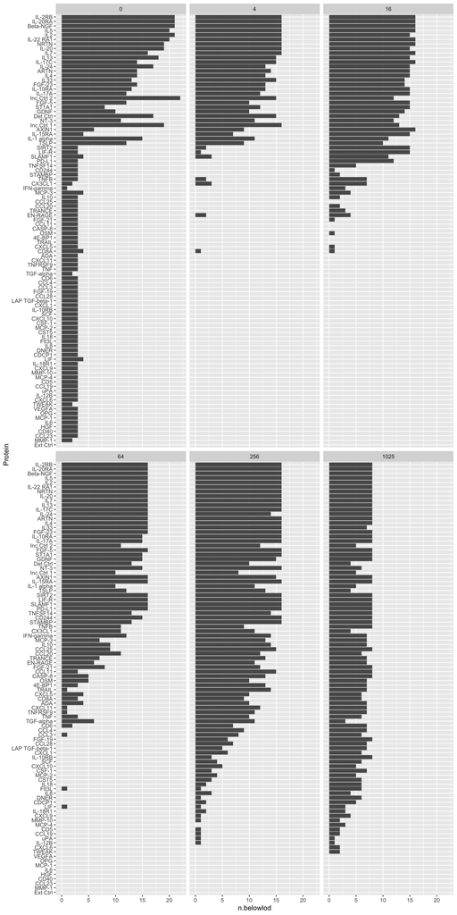

Subset to our 10 high priority proteins

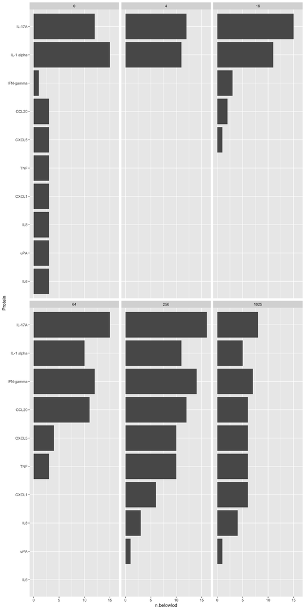

## Observed NPX distribution by assay/protein and dilution

### High priority proteins

Distributions of NPX for the same protein subset, grouped by assay and dilution.

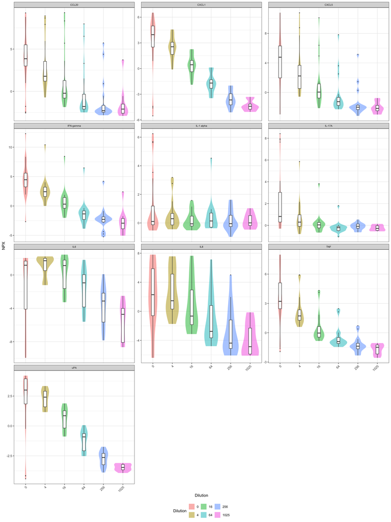

### All remaining proteins

Distributions of NPX by dilution for all remaining assays not in the priority set.

[figure not shown]

# Correlation across dilution conditions for all proteins

To assess measurement consistency across dilution levels, Pearson correlations were computed for each protein between every pair of dilution conditions. For each pair, only individuals with measurements at both dilution levels were included.

The table below summarises the median and mean per-protein correlation for each dilution pair, along with the number of individuals and proteins contributing to each comparison.

| Pair | Dilution 1 | Dilution 2 | N individuals | Median r | Mean r | N proteins |
| --- | --- | --- | --- | --- | --- | --- |
| 0 vs 4 | 0 | 4 | 16 | 0.966 | 0.844 | 95 |
| 4 vs 16 | 4 | 16 | 16 | 0.943 | 0.768 | 95 |
| 0 vs 16 | 0 | 16 | 16 | 0.884 | 0.728 | 95 |
| 16 vs 64 | 16 | 64 | 16 | 0.925 | 0.667 | 95 |
| 4 vs 64 | 4 | 64 | 16 | 0.883 | 0.639 | 95 |
| 0 vs 64 | 0 | 64 | 16 | 0.785 | 0.614 | 95 |
| 64 vs 256 | 64 | 256 | 16 | 0.754 | 0.593 | 95 |
| 16 vs 256 | 16 | 256 | 16 | 0.672 | 0.535 | 95 |
| 4 vs 256 | 4 | 256 | 16 | 0.662 | 0.532 | 95 |
| 0 vs 256 | 0 | 256 | 16 | 0.564 | 0.512 | 95 |
| 16 vs 1025 | 16 | 1025 | 8 | 0.603 | 0.507 | 95 |
| 64 vs 1025 | 64 | 1025 | 8 | 0.571 | 0.497 | 95 |
| 256 vs 1025 | 256 | 1025 | 8 | 0.520 | 0.470 | 95 |
| 4 vs 1025 | 4 | 1025 | 8 | 0.483 | 0.468 | 95 |
| 0 vs 1025 | 0 | 1025 | 8 | 0.460 | 0.408 | 95 |

The violin and box plot below shows the full distribution of per-protein correlations for each dilution pair.

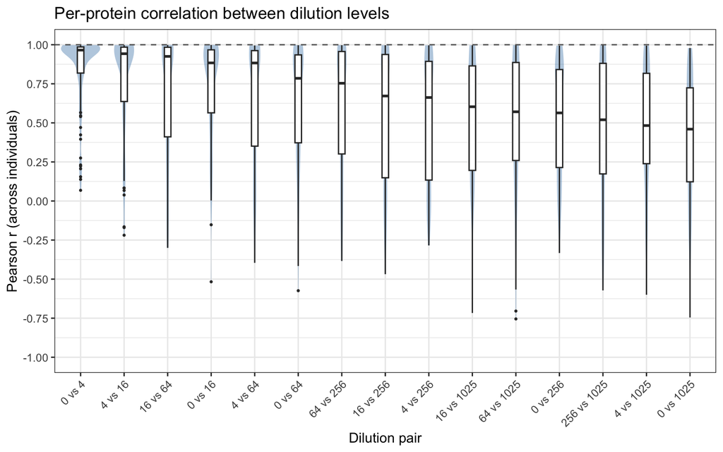

# Pairwise dilution scatter plots for selected proteins

To investigate how individual protein measurements track across dilution levels, scatter plots are shown below for a panel of ten biologically relevant proteins: IL-6, TNF, IL-8, uPA, CXCL1, IFN-γ, CXCL5, IL-17A, IL-1α, and CCL20. These proteins were selected a priori as the key protein targets to have in assay range.

For each protein, every pairwise combination of dilution levels is displayed as a separate panel. Each point represents one individual, with the x- and y-axes showing the NPX value at the two dilution levels being compared. The blue line shows the ordinary least-squares linear fit; the dashed grey line is the identity line (y = x), indicating perfect agreement. The Pearson correlation coefficient (r) is annotated in the top-left corner of each panel.

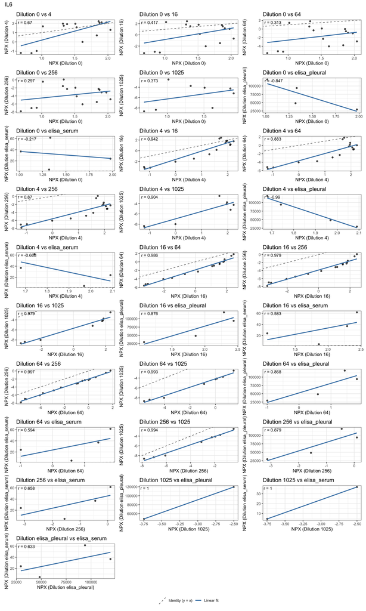

[[1]]

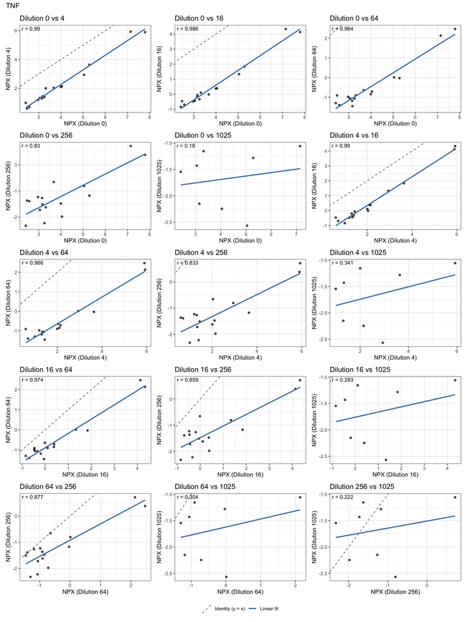

[[2]]

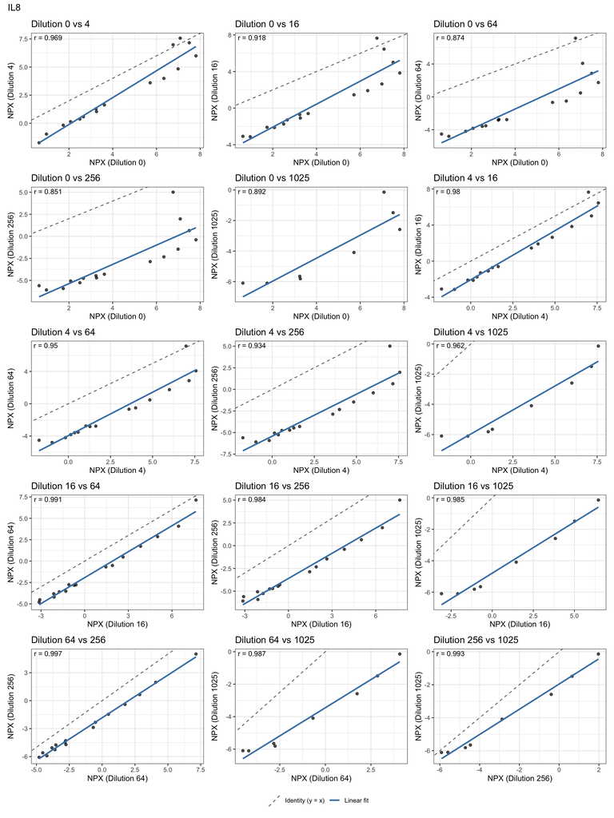

[[3]]

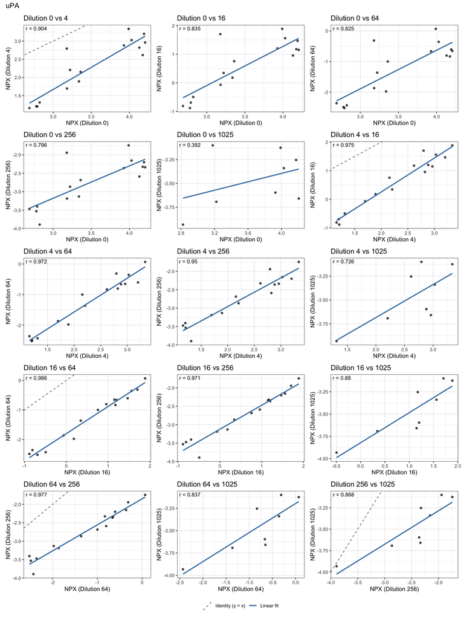

[[4]]

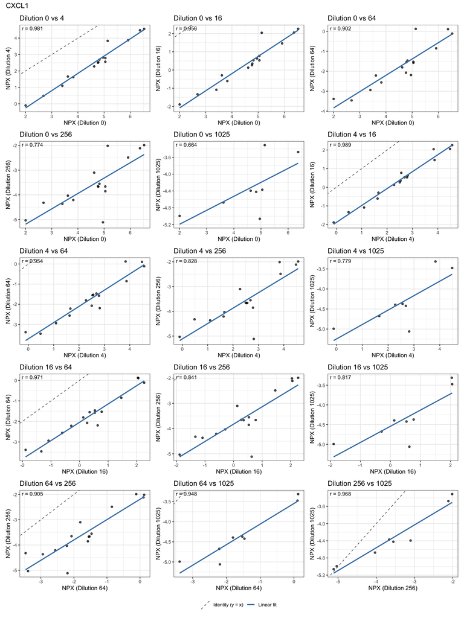

[[5]]

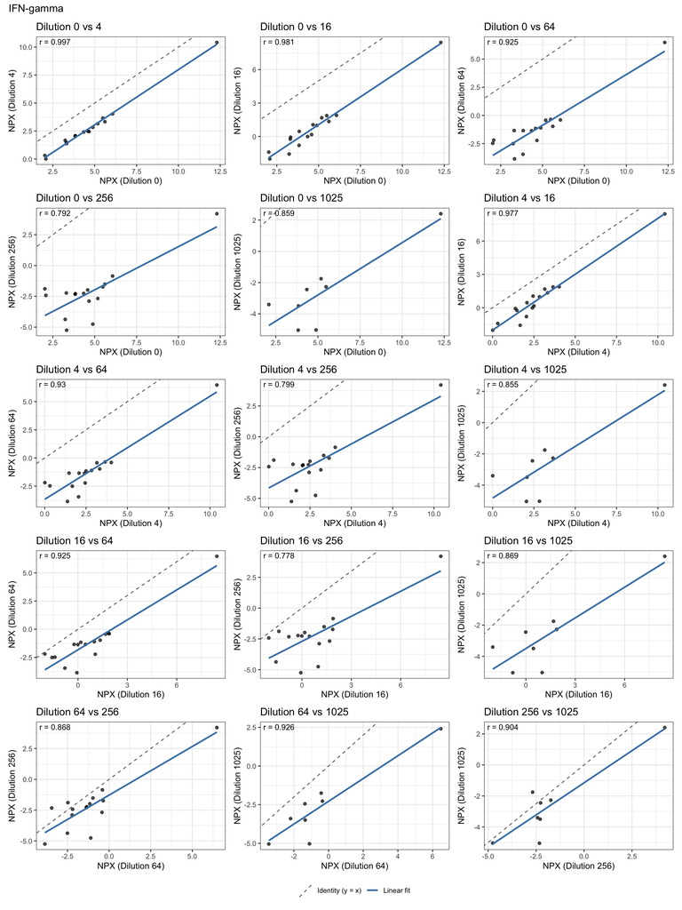

[[6]]

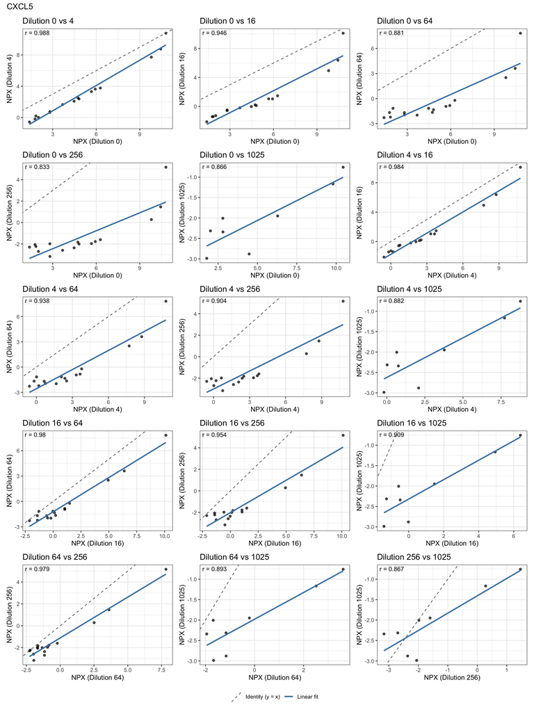

[[7]]

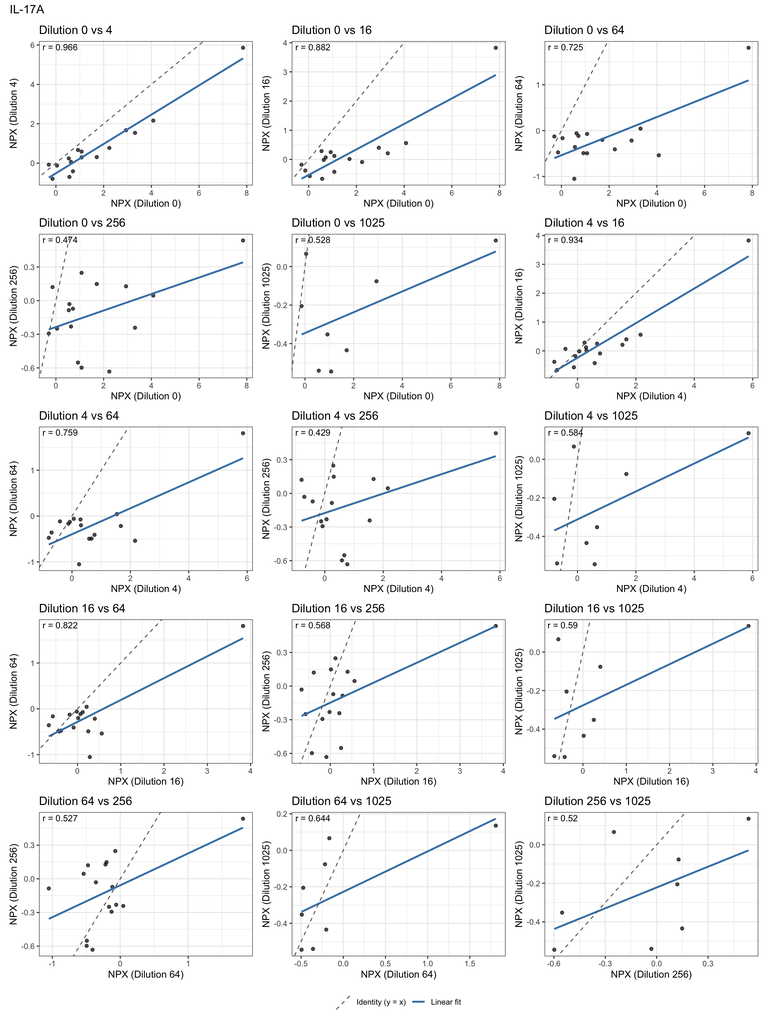

[[8]]

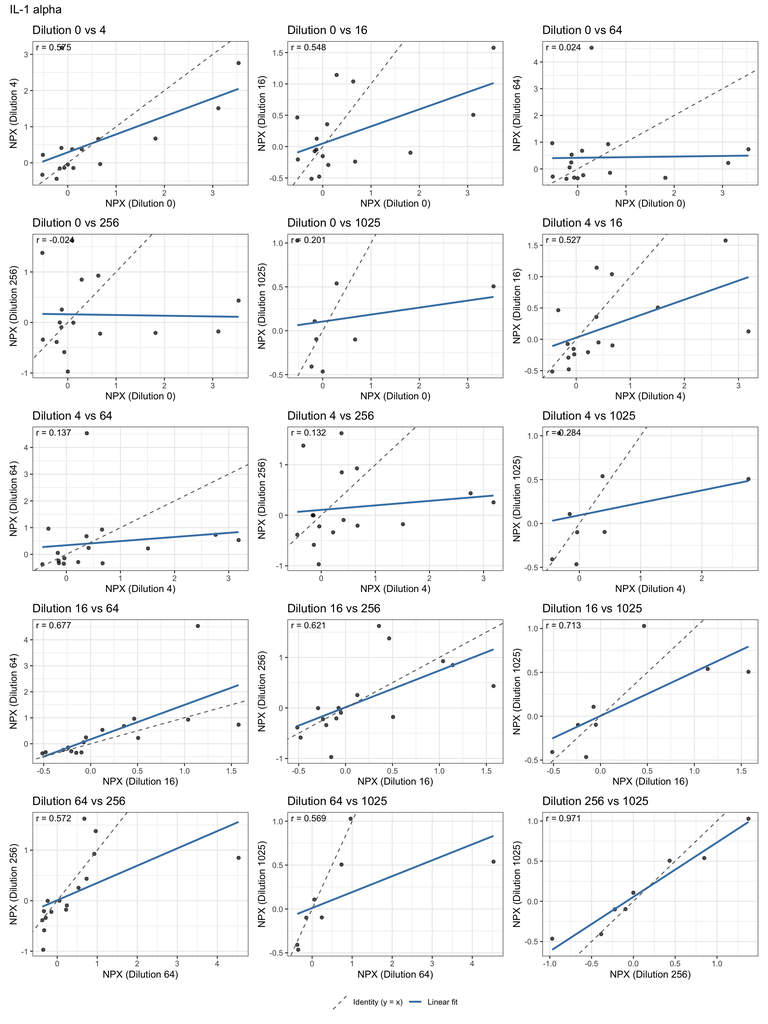

[[9]]

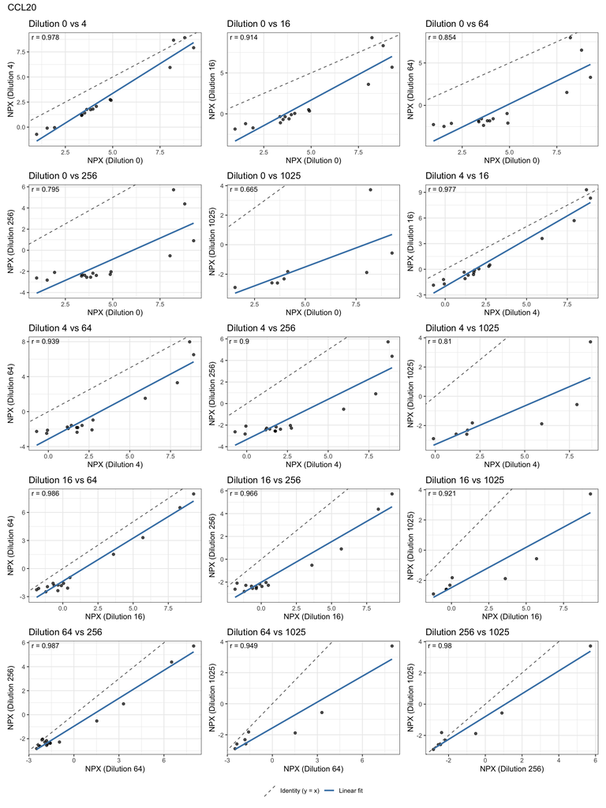

# NPX linearity check

For a protein that is within the assay’s dynamic range, the NPX value should drop by exactly log2(dilution fold-ratio) between adjacent dilution steps. Because all adjacent pairs here represent a 4-fold dilution step, the expected NPX shift is log2(4) = 2 units. The plots below show the distribution of observed shifts (across individuals) for each adjacent dilution pair, with the expected shift shown as a red dashed reference line.

## High priority proteins

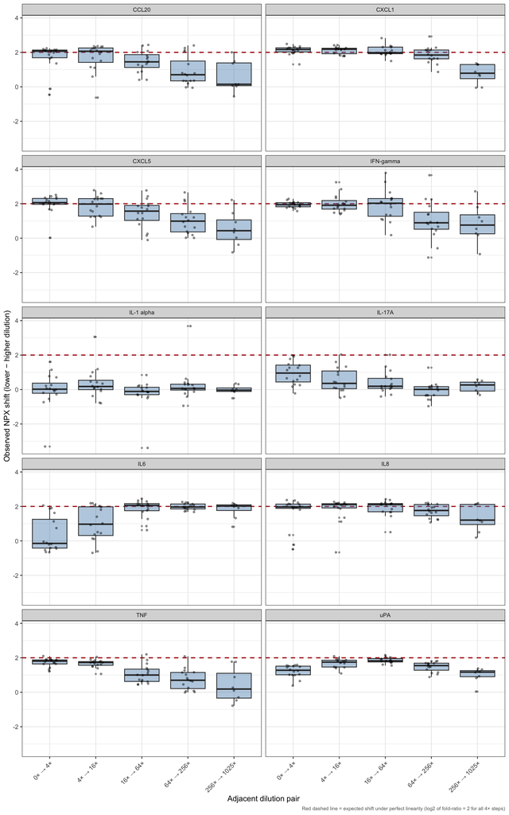

## All remaining proteins

[figure not shown]

# Conclusions

## Limit of detection

- At higher dilution levels, an increasing number of proteins fall below the assay limit of detection (LOD).
- This creates a fundamental trade-off: sufficient dilution is needed to bring high-abundance proteins (most notably IL-6) within the assay’s dynamic range, but excessive dilution risks censoring lower-abundance proteins below the LOD, resulting in loss of quantitative information for those targets.

## Correlation across dilution conditions

- Measurements at adjacent dilution levels are highly concordant: median per-protein Pearson r = 0.97 (0× vs 4×) and 0.94 (4× vs 16×).
- Correlation degrades systematically as the dilution gap widens — median r falls to 0.79 for 0× vs 64×, 0.56 for 0× vs 256×, and 0.46 for 0× vs 1025×.
- This decay suggests that at more extreme dilutions, the rank-ordering of proteins across individuals breaks down, likely reflecting a combination of LOD censoring and increased assay noise at low analyte concentrations.
- The undiluted condition is likely outside the dynamic range for high-abundance proteins such as IL-6, while very high dilutions (256× and above) compromise quantification of lower-abundance targets.
- The moderate dilution range — most plausibly 4× to 16× — represents a good candidate window for balancing these competing considerations, though the selected recommendation should be grounded in the protein-specific scatter plots and ELISA comparisons for the 10 priority targets.
  - For IL6, it looks like the 64x dilution is required to capture the full dynamic range observed in our current sample